# IODS course project

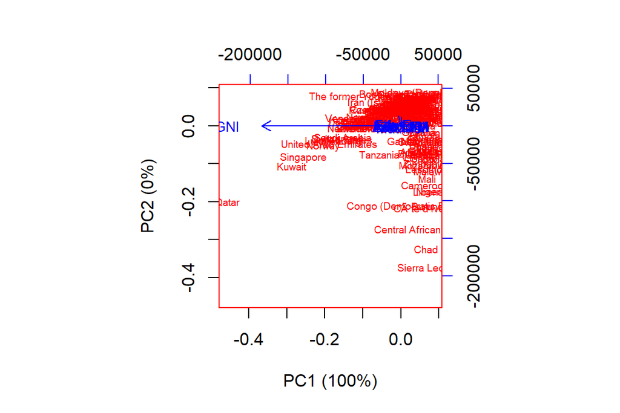

```r
pca_pr <- round(100*summary(pca_human)$importance[2,], digits = 1)
pc_lab <- paste0(names(pca_pr), " (", pca_pr, "%)")
biplot(pca_human, choices = 1:2, cex =c(0.6, 0.8), col = c("red", "blue"), xlab =pc_lab[1], ylab = pc_lab[2])
```

The first non-standardized PCA doesn’t really give much useful information. This can be seen quite clearly from the biplot, where you can’t really make anything out. Also, the PC1 contains 100% of the variance according to this model, which is not useful information. However, in the biplot the PC1 is visible on the x-axis and the PC2 is visible on the y-axis. The arrows visualize how the PCs and the values in the human data connect to each other. Furhtermore, angles between the arrows show correlation between the variables and angles between the axis and arrow show correlation between the variable and the PC. For example small angles between arrows indicate high postitive correlation between variables and small angles between an arrow and a PC axis show high positive correlation between them.

```r
human_std <- scale(human)
```

```r
summary(human_std)
```

```
##     Edu2.FM           Labo.FM           Edu.Exp           Life.Exp
##  Min.   :-2.8189   Min.   :-2.6247   Min.   :-2.7378   Min.   :-2.7188
##  1st Qu.:-0.5233   1st Qu.:-0.5484   1st Qu.:-0.6782   1st Qu.:-0.6425
##  Median : 0.3503   Median : 0.2316   Median : 0.1140   Median : 0.3056
##  Mean   : 0.0000   Mean   : 0.0000   Mean   : 0.0000   Mean   : 0.0000
##  3rd Qu.: 0.5958   3rd Qu.: 0.7350   3rd Qu.: 0.7126   3rd Qu.: 0.6717
##  Max.   : 2.6646   Max.   : 1.6632   Max.   : 2.4730   Max.   : 1.4218
##       GNI             Mat.Mor          Ado.Birth          Parli.F
##  Min.   :-0.9193   Min.   :-0.6992   Min.   :-1.1325   Min.   :-1.8203
##  1st Qu.:-0.7243   1st Qu.:-0.6496   1st Qu.:-0.8394   1st Qu.:-0.7409
##  Median :-0.3013   Median :-0.4726   Median :-0.3298   Median :-0.1403
##  Mean   : 0.0000   Mean   : 0.0000   Mean   : 0.0000   Mean   : 0.0000
##  3rd Qu.: 0.3712   3rd Qu.: 0.1932   3rd Qu.: 0.6030   3rd Qu.: 0.6127
##  Max.   : 5.6890   Max.   : 4.4899   Max.   : 3.8344   Max.   : 3.1850
```

```r
pca_human_std <- prcomp(human_std)
pca_human_std
```

```
## Standard deviations (1, .., p=8):
## [1] 2.0708380 1.1397204 0.8750485 0.7788630 0.6619563 0.5363061 0.4589994
## [8] 0.3222406
##
## Rotation (n x k) = (8 x 8):
##                   PC1         PC2         PC3         PC4        PC5
## Edu2.FM   -0.35664370  0.03796058 -0.24223089  0.62678110 -0.5983585
## Labo.FM    0.05457785  0.72432726 -0.58428770  0.06199424  0.2625067
## Edu.Exp   -0.42766720  0.13940571 -0.07340270 -0.07020294  0.1659678
## Life.Exp  -0.44372240 -0.02530473  0.10991305 -0.05834819  0.1628935
## GNI       -0.35048295  0.05060876 -0.20168779 -0.72727675 -0.4950306
## Mat.Mor    0.43697098  0.14508727 -0.12522539 -0.25170614 -0.1800657
## Ado.Birth  0.41126010  0.07708468  0.01968243  0.04986763 -0.4672068
## Parli.F   -0.08438558  0.65136866  0.72506309  0.01396293 -0.1523699
##                   PC6         PC7         PC8
## Edu2.FM    0.17713316  0.05773644  0.16459453
## Labo.FM   -0.03500707 -0.22729927 -0.07304568
## Edu.Exp   -0.38606919  0.77962966 -0.05415984
## Life.Exp  -0.42242796 -0.43406432  0.62737008
## GNI        0.11120305 -0.13711838 -0.16961173
## Mat.Mor    0.17370039  0.35380306  0.72193946
## Ado.Birth -0.76056557 -0.06897064 -0.14335186
## Parli.F    0.13749772  0.00568387 -0.02306476
```

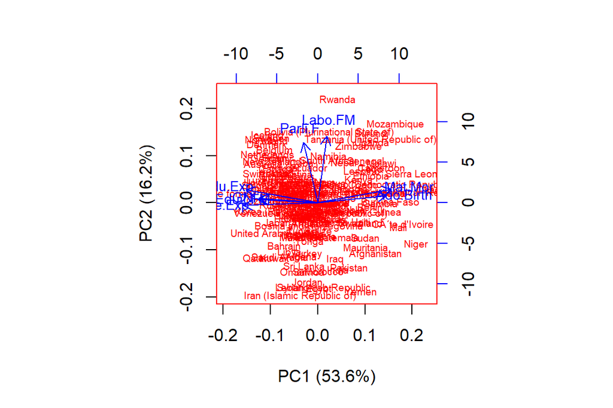

```r
pca_pr_std <- round(100*summary(pca_human_std)$importance[2,], digits = 1)
pc_lab <- paste0(names(pca_pr_std), " (", pca_pr_std, "%)")
biplot(pca_human_std, choices = 1:2, cex =c(0.6, 0.8), col = c("red", "blue"),xlab =pc_lab[1], ylab = pc_lab[2])
```

The biplot of the standardized dataset is much clearer and easier to interpret than the biplot of the original dataset. Also, the results differ from each other as can be seen from the biplots. Now PC1 accounts for 53.6% and PC2for 16.2% of the variance. When we standardize a dataset, we scale it down, so that the values don’t have as much variance between each other. This is useful in PCA, since it assumes that variables with large variances are more important than other, which can be misleading in the results. The variables also assume values that are easier to compare.This is the reason to why the results are different. The correlations haven’t, however, changed. the arros are seen more clearly in the standardized biplot, but the relations between them are the same. This happens because the standard deviation changes, which can be seen from the summaries of the original and then standardized datasets.

Interpreting hte results The standardized biplot is still a bit hard to interpret, it would be much easier if it was a bit bigger, but unfortunately I don’t know how to make it bigger yet. According to the standardized biplot PC1 correlates to variables connected to health, such as life.exp, mat.mot, edu.exp and ado.birth. PC2 correlates with variables connected to equality, such as parli.F and labo.FM. 3 different clusters can be seen from the standardized biplot. Two of them are almost on top of each other, but one is slightly below the other. Another one is above the other two. The different places of the clusters depend on how much they are affected by variables that correlate with PC1 and PC2. It would be interesting to see which countries are in which cluster, but I can’t quite make out the text, other than some african countries in the top right. Thismeans that the correlate positively with mat.mor and ado.birth and also somewhat with labo.FM. How the arrows are arranged in the biplot depends on how the variables correlate with PC1, PC2 and each other. As earlier explained, small angles mean that the correlation is highly positive and largeangles (for example 180 degrees) indicate a highly negative correlation. The arrows (variables) show both correlation between the different variables and PC1 and PC2.

# Chapter 6 begins here

This week we are learning about longitudinal data. Longitudinal data is the name of data where multiple measurements is done at different times on the same subject. That way, we get multiple responses for each variable. The different measurements are intercorrelated,and the different variables measured can also be correlated to each oter. Hence,we can have two different types of dependecies in the data.

```r
BPRS <- read.table("https://raw.githubusercontent.com/KimmoVehkalahti/MABS/master/Examples/data/BPRS.txt", sep  =" ", header = T)
RATS <- read.table("https://raw.githubusercontent.com/KimmoVehkalahti/MABS/master/Examples/data/rats.txt", header = TRUE, sep = '\t')

# Access the packages dplyr and tidyr
library(dplyr)
library(tidyr)

# Factor ID and Group
RATS$ID <- factor(RATS$ID)
RATS$Group <- factor(RATS$Group)

# Convert to long form and extract day numbers from WD
RATSL <- RATS %>% gather(key = WD, value = Weight, -ID, -Group) %>% mutate(Time = as.integer(substr(WD, 3,4)))

# Factor treatment & subject
BPRS$treatment <- factor(BPRS$treatment)
BPRS$subject <- factor(BPRS$subject)

# Convert to long form
BPRSL <-  BPRS %>% gather(key = weeks, value = bprs, -treatment, -subject)

# Extract the week number
BPRSL <-  BPRSL %>% mutate(week = as.integer(substr(weeks,5,5)))
```

The first data used this week is the RATS data. It consists of observations of rats’ weights and weight-changes during a nine week period. The rats are separated into three different groups, and each group is put on different diets. In the second data, the BPRS, 40 males have been assigned to two different treatments. 18 symptoms, such as hostility, hallucinations, grandiosity and suspiciousness are being observed in the males weeklyfor 8 weeks. The observations are based on a brief psychiatric rating score (BPRS), which gives each symptom a score from 0 (not present) to seven (extremely severe). This scale helps to evaluate whether a patient suffers from schizofrenia or not.

```r
names(RATSL)
```

```
## [1] "ID"     "Group"  "WD"     "Weight" "Time"
```

```r
str(RATSL)
```

```
## 'data.frame':    176 obs. of  5 variables:
##  $ ID    : Factor w/ 16 levels "1","2","3","4",..: 1 2 3 4 5 6 7 8 9 10 ...
##  $ Group : Factor w/ 3 levels "1","2","3": 1 1 1 1 1 1 1 1 2 2 ...
##  $ WD    : chr  "WD1" "WD1" "WD1" "WD1" ...
##  $ Weight: int  240 225 245 260 255 260 275 245 410 405 ...
##  $ Time  : int  1 1 1 1 1 1 1 1 1 1 ...
```

```r
summary(RATSL)
```

```
##        ID      Group       WD                Weight           Time
##  1      : 11   1:88   Length:176         Min.   :225.0   Min.   : 1.00
##  2      : 11   2:44   Class :character   1st Qu.:267.0   1st Qu.:15.00
##  3      : 11   3:44   Mode  :character   Median :344.5   Median :36.00
##  4      : 11                             Mean   :384.5   Mean   :33.55
##  5      : 11                             3rd Qu.:511.2   3rd Qu.:50.00
##  6      : 11                             Max.   :628.0   Max.   :64.00
##  (Other):110
```

```r
names(BPRSL)
```

```
## [1] "treatment" "subject"   "weeks"     "bprs"      "week"
```

```r
str(BPRSL)
```

```
## 'data.frame':    360 obs. of  5 variables:
##  $ treatment: Factor w/ 2 levels "1","2": 1 1 1 1 1 1 1 1 1 1 ...
##  $ subject  : Factor w/ 20 levels "1","2","3","4",..: 1 2 3 4 5 6 7 8 9 10 ...
##  $ weeks    : chr  "week0" "week0" "week0" "week0" ...
##  $ bprs     : int  42 58 54 55 72 48 71 30 41 57 ...
##  $ week     : int  0 0 0 0 0 0 0 0 0 0 ...
```

```r
summary(BPRSL)
```

```
##  treatment    subject       weeks                bprs            week
##  1:180     1      : 18   Length:360         Min.   :18.00   Min.   :0
##  2:180     2      : 18   Class :character   1st Qu.:27.00   1st Qu.:2
##            3      : 18   Mode  :character   Median :35.00   Median :4
##            4      : 18                      Mean   :37.66   Mean   :4
##            5      : 18                      3rd Qu.:43.00   3rd Qu.:6
##            6      : 18                      Max.   :95.00   Max.   :8
##            (Other):252
```

I will be using the data in the long form, i.e. RATSL and BPRSL